# Modifying the input structure

## Introduction

We assume you went through the getting started vignette and also the basic modification vignette.

If the modifications you can achieve by providing optional settings to `prepare_diagram` and `make_diagram`, then you do not need to go any further, and there is no need to understand in more detail how **flowdiagramr** works. However, it is quite likely that at some point, you want to further tweak your diagram. To do so successfully, it is useful to learn some more details about how the package works.

As you learned, producing a diagram with **flowdiagramr** involves two steps. After you have defined your model, there is a first step in which you call `prepare_diagram`, which takes your model and creates a list of data frames (which we called the `input_structure` in the prior vignettes). These data frames are used by `make_diagram` to produce the ggplot code and figure.

The advantage of this 2-step process is that you can make modifications to the `input_structure` object before sending it into the `make_diagram` function, and thus modify the layout of the diagram beyond what you can through the`make_diagram` options, while still being fairly easy to do.

## Explanation of the `diagram_list` object

To modify the object returned from `prepare_diagram` and used as input for `make_diagram`, it is important to learn a bit about it. You can learn the details from the help file for the `prepare_diagram` function, which you can call like this

```r
help('prepare_diagram')
```

As the help file explains, what `prepare_diagram` does is to produce a list (which we call `diagram_list`, but you can assign it any name) that contains 2 data frames, one with variable related information and one with flow related information. This information is used by `make_diagram` to create the plot.

`prepare_diagram` attempts to make reasonable choices on location and sizing for variables and flows. For example, flows into or out of the system with only one node intersection are typically drawn at a 45 degree angle. Flows that bypass a node are typically curved.

Once you understand the components of the input object and what the different parts mean, you can modify them. This allows you to impact the look of the diagram you get once you send your modified object into the `make_diagram` function.

It is easiest to understand this approach by showing a few examples, so let’s do that.

## Modifying the `make_diagram` input object

### Example 1

Let’s revisit the SIR model from the basic modification vignette. First we set up the model.

```r
#Set up model
varlabels = c("S","I","R")
flows = list(S_flows = c("n", "-b*S*I", "-m*S"),
             I_flows = c("b*S*I","-g*I", "-m*I"),
             R_flows = c("g*I", "-m*R"))
sirmodel = list(varlabels = varlabels, flows = flows)
```

Next, we send the model to the `prepare_diagram` function.

```r
sir_diagram_list <- prepare_diagram(sirmodel)
```

Now, let’s make and plot the diagram. For this plot, we also turned on the grid. This is useful in figuring out by how much to shift things around.

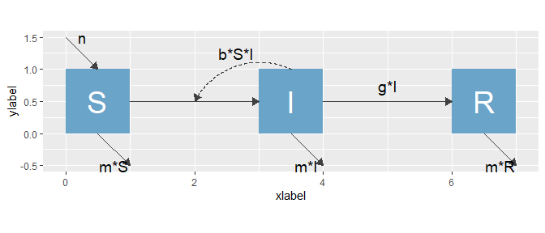

```r
plot1 <- make_diagram(sir_diagram_list, diagram_settings = list(with_grid = TRUE))
plot(plot1)
```

So far, nothing really new, apart from showing the grid in the plot.

Now, instead of sending the object produced by `prepare_diagram` (here called `sir_diagram_list`) to the `make_diagram` function right away, we’ll take a look at it and modify it. Here are the details contained in this object

```r
print(sir_diagram_list, row.names = FALSE)
```

```
#> $variables
#>  label id name xmin xmax ymin ymax xlabel ylabel color    fill label_color
#>      S  1    S    0    1    0    1    0.5    0.5    NA #6aa4c8       white
#>      I  2    I    3    4    0    1    3.5    0.5    NA #6aa4c8       white
#>      R  3    R    6    7    0    1    6.5    0.5    NA #6aa4c8       white
#>  label_size
#>          10
#>          10
#>          10
#>
#> $flows
#>  id   to from label xmin xmax ymin ymax xlabel ylabel curvature        type
#>   1    I    S        1.0  3.0  0.5  0.5   2.00   0.75       0.0        main
#>   2    R    I   g*I  4.0  6.0  0.5  0.5   5.00   0.75       0.0        main
#>   3    S <NA>     n  0.0  0.5  1.5  1.0   0.25   1.50       0.0    external
#>   4 <NA>    S   m*S  0.5  1.0  0.0 -0.5   0.75  -0.50       0.0    external
#>   5 <NA>    I   m*I  3.5  4.0  0.0 -0.5   3.75  -0.50       0.0    external
#>   6 <NA>    R   m*R  6.5  7.0  0.0 -0.5   6.75  -0.50       0.0    external
#>   7 <NA>    I b*S*I  3.5  2.0  1.0  0.5   2.65   1.25       0.4 interaction
#>   math  color linetype size label_color label_size arrowsize
#>        grey25    solid  0.7       black          5      0.25
#>    g*I grey25    solid  0.7       black          5      0.25
#>      n grey25    solid  0.7       black          5      0.25
#>    m*S grey25    solid  0.7       black          5      0.25
#>    m*I grey25    solid  0.7       black          5      0.25
#>    m*R grey25    solid  0.7       black          5      0.25
#>  b*S*I grey25   dashed  0.7       black          5      0.25
#>
#> $inputs
#> $inputs$model_list
#> $inputs$model_list$varlabels
#> [1] "S" "I" "R"
#>
#> $inputs$model_list$flows
#> $inputs$model_list$flows$S_flows
#> [1] "n"      "-b*S*I" "-m*S"
#>
#> $inputs$model_list$flows$I_flows
#> [1] "b*S*I" "-g*I"  "-m*I"
#>
#> $inputs$model_list$flows$R_flows
#> [1] "g*I"  "-m*R"
#>
#>
#>
#> $inputs$model_settings
#> $inputs$model_settings$varlocations
#> NULL
#>
#> $inputs$model_settings$varbox_x_size
#> [1] 1
#>
#> $inputs$model_settings$varbox_y_size
#> [1] 1
#>
#> $inputs$model_settings$varspace_x_size
#> [1] 1
#>
#> $inputs$model_settings$varspace_y_size
#> [1] 1
```

Let’s modify this object somewhat. The following code makes the `I` box bigger, and moves the inflow and outflow arrows such that they start/end on the box with the new size. It also shifts the curved arrow and adjusts the label positioning.

```r
#assign to a new variable so we preserve the original
modified_diagram_list <- sir_diagram_list
#increase the I box a bit both on left and right
modified_diagram_list$variables$xmin[2] = 2
modified_diagram_list$variables$xmax[2] = 5
#modify inflow and outflow arrows to align with new box size
modified_diagram_list$flows$xmax[1] = 2
modified_diagram_list$flows$xmin[2] =5
#move the b*S*I arrow end a bit
modified_diagram_list$flows$xmax[7] = 1.5
#move the b*S*I label
modified_diagram_list$flows$ylabel[7] = 1.25
modified_diagram_list$flows$xlabel[7] = 2
#move the g*I arrow over just a bit
modified_diagram_list$flows$xlabel[2] = 5.5
```

With those modifications, the resulting diagram looks like this

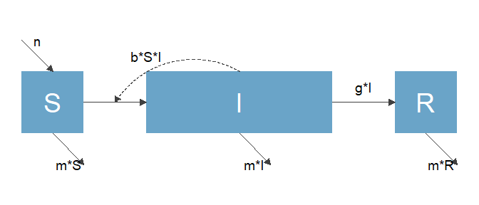

```r
plot2 <- make_diagram(modified_diagram_list)
plot(plot2)
```

It is possible to combine the modification of the diagram with modifications made through settings in `make_diagram`, e.g., we can add some color like this

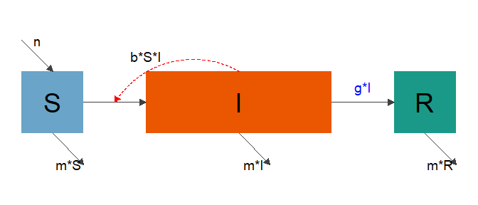

```r
diagram_settings = list(var_fill_color = c("#6aa4c8", "#eb5600", "#1a9988"),
                          var_label_color = "black",
                          main_flow_label_color = "blue",
                          interaction_flow_color = "red")
plot3 <- make_diagram( modified_diagram_list, diagram_settings)
plot(plot3)
```

**Important Note:** If you supply settings for a specific element to `make_diagram` through the `diagram_settings` input, those take precedence over entries in `diagram_list`. Thus, if you make manual adjustments to `diagram_list`, make sure that you don’t apply further styling to that component in `diagram_settings`. For instance if you decided to change the label color for the variables by editing `diagram_list`, you should not provide a `var_label_color` entry in `diagram_settings`.

Here is a quick example. We change the color of the `I` variable to red, which results in the first plot. But once we supply color specifications through `diagram_settings`, this is overwritten. As the third plot shows, it is easiest to make multiple specifications through `diagram_settings` rather than `diagram_list` because `diagram_settings` always takes priority.

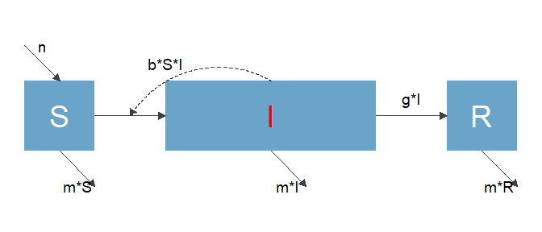

```r
#manually change label color
modified_diagram_list$variables$label_color[2] = "red"
diag1 <- make_diagram(modified_diagram_list)
plot(diag1)
```

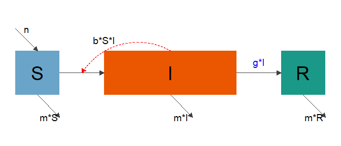

```r
#var_label_color is overwritten by values from diagram_settings
diag2 <- make_diagram(modified_diagram_list, diagram_settings)
plot(diag2)
```

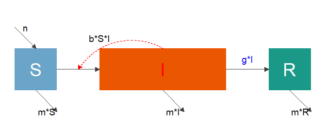

```r
#explicitly define the vector of label colors
diagram_settings$var_label_color <- c("white", "red", "white")
diag3 <- make_diagram(modified_diagram_list, diagram_settings)
plot(diag3)
```

### Example 2

Here is another example, the predator prey model you saw in earlier vignettes.

Setting up the model:

```r
varlabels = c("Pat","Imm")
flows     = list(Pat_flows = c("g*Pat*(1-Pat/pmax)", "-dP*Pat", "-k*Pat*Imm"),
                 Imm_flows = c("r*Pat*Imm", "-dI*Imm"))
mymodel = list(varlabels = varlabels, flows = flows)
```

Preparing the diagram and making the plot.

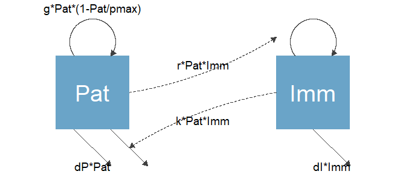

```r
diagram_list <- prepare_diagram(mymodel)
ppplot <- make_diagram(diagram_list)
plot(ppplot)
```

Let’s modify this. We’ll make the boxes a bit wider, relabel them, and adjust the location of some of the flows to work with the different box sizes. We’ll also move some flow labels around and let’s also assume that we want the parameter that specifies the maximum pathogen level at which growth goes to zero to be called `Pmax`, not `pmax`. We can’t do that when you specify the model since **flowdiagramr** requires that parameters start with a lower case letter. Not a big deal, we can fix this now by replacing the label.

First, we’ll look at the `diagram_list` structure to see which elements we need to change.

```r
print(diagram_list, row.names = FALSE)
```

```
#> $variables
#>  label id name xmin xmax ymin ymax xlabel ylabel color    fill label_color
#>    Pat  1  Pat    0    1    0    1    0.5    0.5    NA #6aa4c8       white
#>    Imm  2  Imm    3    4    0    1    3.5    0.5    NA #6aa4c8       white
#>  label_size
#>          10
#>          10
#>
#> $flows
#>  id   to from              label xmin xmax ymin  ymax xlabel ylabel curvature
#>   1  Pat  Pat g*Pat*(1-Pat/pmax) 0.25 0.75  1.0  1.00   0.50  1.650      -2.0
#>   2  Imm  Imm                    3.25 3.75  1.0  1.00   3.50  1.650      -2.0
#>   3 <NA>  Pat             dP*Pat 0.25 0.75  0.0 -0.50   0.50 -0.500       0.0
#>   4 <NA>  Pat                    0.75 1.25  0.0 -0.50   1.00 -0.500       0.0
#>   5 <NA>  Imm             dI*Imm 3.50 4.00  0.0 -0.50   3.75 -0.500       0.0
#>   6  Pat  Imm          k*Pat*Imm 3.00 1.00  0.5 -0.25   2.00  0.125       0.1
#>   7  Imm  Pat          r*Pat*Imm 1.00 3.00  0.5  1.25   2.00  0.875       0.1
#>         type               math  color linetype size label_color label_size
#>         main g*Pat*(1-Pat/pmax) grey25    solid  0.7       black          5
#>         main                    grey25    solid  0.7       black          5
#>     external             dP*Pat grey25    solid  0.7       black          5
#>     external                    grey25    solid  0.7       black          5
#>     external             dI*Imm grey25    solid  0.7       black          5
#>  interaction          k*Pat*Imm grey25   dashed  0.7       black          5
#>  interaction          r*Pat*Imm grey25   dashed  0.7       black          5
#>  arrowsize
#>       0.25
#>       0.25
#>       0.25
#>       0.25
#>       0.25
#>       0.25
#>       0.25
#>
#> $inputs
#> $inputs$model_list
#> $inputs$model_list$varlabels
#> [1] "Pat" "Imm"
#>
#> $inputs$model_list$flows
```

[output cut: 8 more lines]

```
#> $inputs$model_settings
#> $inputs$model_settings$varlocations
#> NULL
#>
#> $inputs$model_settings$varbox_x_size
#> [1] 1
#>
#> $inputs$model_settings$varbox_y_size
#> [1] 1
#>
#> $inputs$model_settings$varspace_x_size
#> [1] 1
#>
#> $inputs$model_settings$varspace_y_size
#> [1] 1
```

And here is the code that makes some changes

```r
#increase boxes
diagram_list$variables$xmin[1] = -0.25
diagram_list$variables$xmax[1] = 1.25
diagram_list$variables$xmin[2] = 2.75
diagram_list$variables$xmax[2] = 4.25
#relabel boxes
diagram_list$variables$label[1] = "Pat \n (Bacteria)"
diagram_list$variables$label[2] = "Imm \n (T cells)"
#adjust arrow locations to start/end at box edges
diagram_list$flows$xmin[6] <- 2.75
diagram_list$flows$xmin[7] <- 1.25
diagram_list$flows$xmax[7] <- 3.2
#move k*Pat*Imm label
diagram_list$flows$ylabel[6] <- 0.1
#change label
diagram_list$flows$label[1] <- "g*Pat*(1-Pat/Pmax)"
```

Sure enough, if you plot this now, you can see all your improvements.

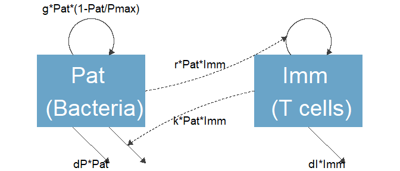

```r
my_diagram <- make_diagram(diagram_list)
plot(my_diagram)
```

### Example 3

Finally, let’s briefly revisit our 7-compartment model and see if we can make some further tweaks to get it to something that might be suitable for public use.

Here is the model specification again

```r
varlabels = c("Sc","Ic","Rc","Sa","Ia","Ra","P")
flows = list(Sc_flows = c("-Sc*bcc*Ic","-Sc*bca*Ia","-Sc*bcp*P"),
             Ic_flows = c("Sc*bcc*Ic","Sc*bca*Ia","Sc*bcp*P","-gc*Ic"),
             Rc_flows = c("gc*Ic"),
             Sa_flows = c("-Sa*bac*Ic","-Sa*baa*Ia","-Sa*bap*P"),
             Ia_flows = c("Sa*bac*Ic","Sa*baa*Ia","Sa*bap*P","-ga*Ia"),
             Ra_flows = c("ga*Ia"),
             P_flows = c("sc*Ic","sa*Ia","-d*P")
             )
mymodel = list(varlabels = varlabels, flows = flows)

varnames = c("Susceptible\nChildren","Infected\nChildren","Recovered\nChildren",
             "Susceptible\nAdults","Infected\nAdults","Recovered\nAdults",
             "Pathogen\nin\nEnvironment")
varlocations = matrix(data = c("Sc", "Ic", "Rc",
                               "",   "P",   "",
                               "Sa", "Ia", "Ra"),nrow = 3, byrow = TRUE)
mysettings = list(varlocations = varlocations)
diagram_list <- prepare_diagram(mymodel, mysettings)
```

If you print the resulting `diagram_list`, you can see details for each box/variable and arrow/flow. Since this is big, we are not showing it here. But we’ll go ahead and make some modifications.

The main problems are the location of the labels and some of the arrows, so let’s move them around.

```r
# change some of the flow arrows
diagram_list$flows$xstart[11] <- 2.5
diagram_list$flows$ystart[11] <- 0
diagram_list$flows$xstart[10] <- 2.5
diagram_list$flows$ystart[10] <- -2
diagram_list$flows$xstart[13] <- 2.5
diagram_list$flows$ystart[13] <- -2
diagram_list$flows$curvature[9] <- - 0.5
diagram_list$flows$curvature[10] <- - 0.5

# change location of flow labels
diagram_list$flows$labelx[5] <- 3.75
diagram_list$flows$labely[5] <- -3
diagram_list$flows$labelx[7] <- 2.75
diagram_list$flows$labelx[9] <- 0.75
diagram_list$flows$labely[9] <- -1
diagram_list$flows$labelx[10] <- 2
diagram_list$flows$labely[10] <- -1.75
diagram_list$flows$labelx[11] <- 0.75
diagram_list$flows$labely[11] <- -2
diagram_list$flows$labelx[13] <- 2
```

Finally, we make the diagram, and also apply custom styling as previously

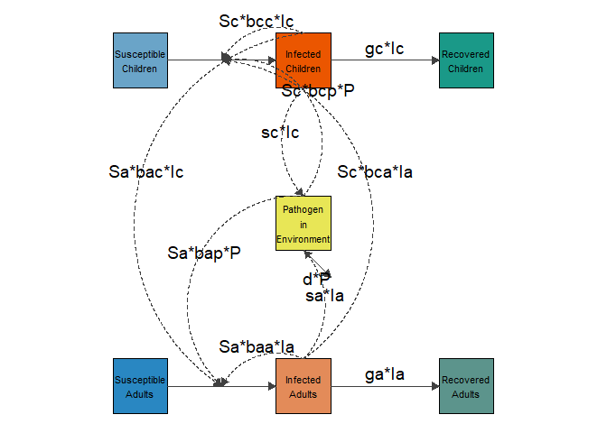

```r
diagram_settings <- list(
                        var_fill_color = c("#6aa4c8", "#eb5600", "#1a9988", "#2987c2", "#e38b59", "#5c948c", "#e8e656"),
                        var_outline_color = "black",
                        var_label_color = "black",
                        var_label_text = varnames,
                        var_label_size = 3
                        )
model_plot <- make_diagram(diagram_list, diagram_settings)
plot(model_plot)
```

Ok, this was a bit tedious, but it’s pretty close to a diagram that could be used for public consumption.

## Next steps

You now learned two ways that allow you to customize the diagram in a fairly easy way. The first approach is through optional arguments to `make_diagram` and `prepare_diagram`, and the second approach is the one we just discussed. They can be combined.

We expect that this is often enough to give you a diagram that’s good enough for what you want. However, at times you might want to make further changes. For instance you might want to change specific elements, add text to the diagram, or perform other fine tuning. **flowdiagramr** gives you a way of doing this, which is described in the modifying the ggplot2 code vignette, which you should read next.